# BUDT758X

- Professor: Sean Barnes
- students:
  - Xukun LIU (www.xukun-liu.com)
  - Nichola Summers
- Topics: Data Visualization

Diamonds are the crown jewel of the jewelry industry. As a luxury item, there is a broad range of quality-related characteristics and prices, designed to accommodate many customer segments. The attached data filePreview the document contains sample data on 6,000 diamonds. Each row contains a summary of characteristics for each diamond, including:

- the 4 C's (carat weight, color, clarity, cut),
- polish,
- symmetry,
- certifying agency (report),
- and price. More information on the 4 C's can be found at this link (Links to an external site.).

Use appropriate techniques for data analysis and visualization, along with relevant features in matplotlib, pandas, and Seaborn to create two high-quality visualization exhibits of your choice. You will be graded on the quality of the visualizations and your explanations of the insights, but also the richness of your story.

After submitting your Jupyter Notebook for the assignment, please also post your visualizations and descriptions to the Discussion board so that the entire class can view. This will create an online showcase for the interesting ideas generated by your classmates.

```python
import pandas as pd
import matplotlib.pyplot as plt
import seaborn as sb
```

```python
dt = pd.read_csv('diamonds.csv')
```

```python
dt.head()
```

|  | ID | Carat Weight | Cut | Color | Clarity | Polish | Symmetry | Report | Price |
| --- | --- | --- | --- | --- | --- | --- | --- | --- | --- |
| 0 | 1 | 1.10 | Ideal | H | SI1 | VG | EX | GIA | 5169 |
| 1 | 2 | 0.83 | Ideal | H | VS1 | ID | ID | AGSL | 3470 |
| 2 | 3 | 0.85 | Ideal | H | SI1 | EX | EX | GIA | 3183 |
| 3 | 4 | 0.91 | Ideal | E | SI1 | VG | VG | GIA | 4370 |
| 4 | 5 | 0.83 | Ideal | G | SI1 | EX | EX | GIA | 3171 |

```python
plt.style.use('ggplot')
```

```python
Colors = list(dt.Color.value_counts().index)
Colors_count = list(dt.Color.value_counts())
cut_rank = ['Fair','Good','Very Good','Ideal','Signature-Ideal']
```

```
(0, 6000)
```

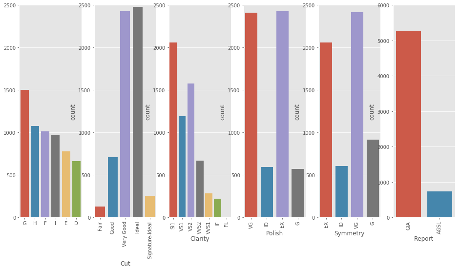

```python
plt.figure(figsize=(16,8))

plt.subplot(1,6,1)
sb.barplot(x=Colors,y=Colors_count)
plt.ylim(0,2500)

plt.subplot(1,6,2)
sb.countplot(x=dt.Cut,order=cut_rank)
plt.xticks(rotation=90)
plt.ylim(0,2500)

plt.subplot(1,6,3)
sb.countplot(x = 'Clarity',data = dt)
plt.xticks(rotation=90)
plt.ylim(0,2500)

plt.subplot(1,6,4)
sb.countplot(x = 'Polish',data = dt)
plt.xticks(rotation=90)
plt.ylim(0,2500)

plt.subplot(1,6,5)
sb.countplot(x='Symmetry',data = dt)
plt.xticks(rotation=90)
plt.ylim(0,2500)

plt.subplot(1,6,6)
sb.countplot(x='Report',data = dt)
plt.xticks(rotation=90)
plt.ylim(0,6000)
```

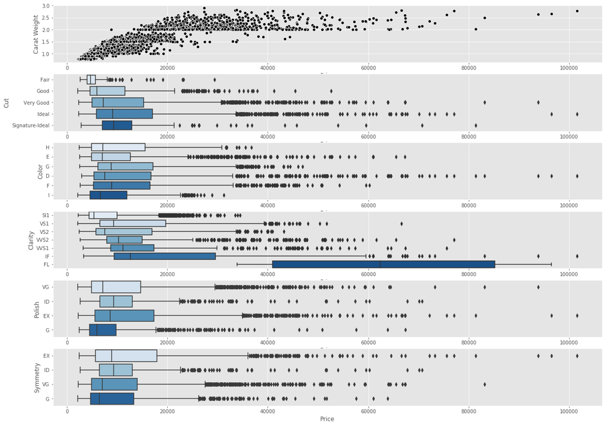

```python
plt.figure(figsize=(20,15))

plt.subplot(6,1,1)
sb.scatterplot(x='Price',y='Carat Weight',data=dt,color='k')

plt.subplot(6,1,2)
sb.boxplot(x='Price',y='Cut',data=dt,palette='Blues',order=cut_rank)

plt.subplot(6,1,3)
sb.boxplot(x='Price',y='Color',data=dt,palette='Blues')

plt.subplot(6,1,4)
sb.boxplot(x='Price',y='Clarity',data=dt,palette='Blues')

plt.subplot(6,1,5)
sb.boxplot(x='Price',y='Polish',data=dt,palette='Blues')

plt.subplot(6,1,6)
sb.boxplot(x='Price',y='Symmetry',data=dt,palette='Blues')
```

**Analysis:**

- From the above plots, we could tell the diamonts' prices are strongly affected by:
  - Carat Weight
  - Clarity
  - Color
  - Polish
- In the following part, we are going to analyze how do they affect the price

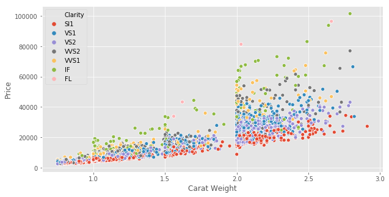

```python
plt.figure(figsize=(10,5))
sb.scatterplot(x='Carat Weight', y="Price", hue = 'Clarity', data=dt)
```

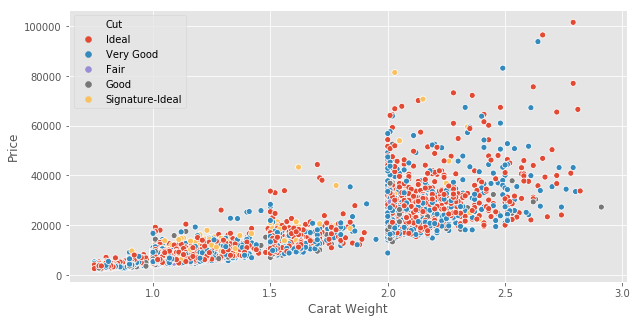

```python
plt.figure(figsize=(10,5))
sb.scatterplot(x='Carat Weight', y="Price", hue = 'Cut', data=dt)
```

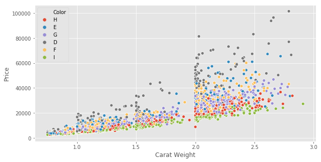

```python
plt.figure(figsize=(10,5))
sb.scatterplot(x='Carat Weight', y="Price", hue='Color', data=dt)
```

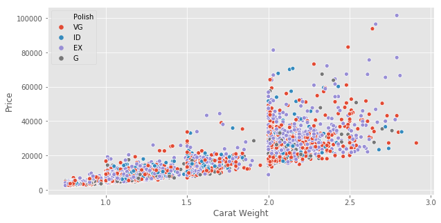

```python
plt.figure(figsize=(10,5))
sb.scatterplot(x='Carat Weight', y="Price", hue='Polish', data=dt)
```

**Analysis:**